# Exploring prosperLoanData by Tang Shuran

# Univariate Plots Section

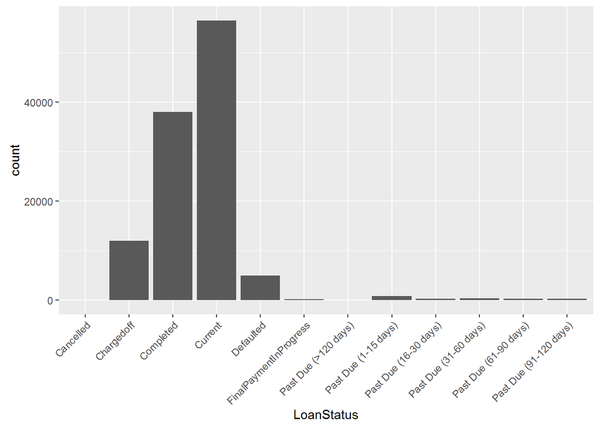

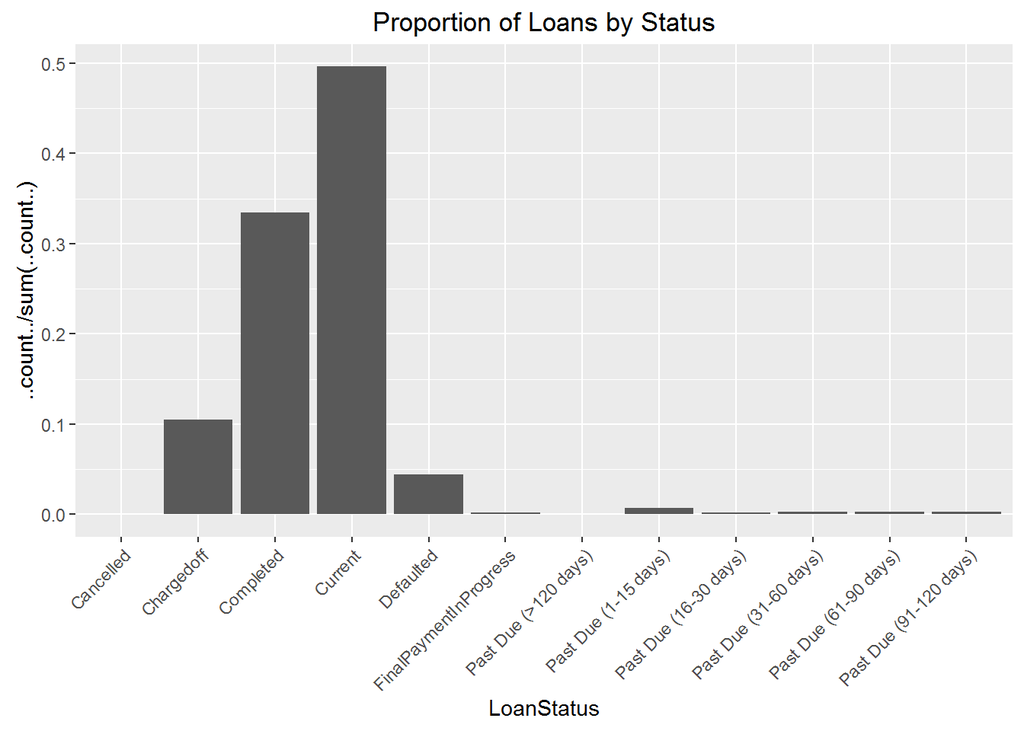

```
##              Cancelled             Chargedoff              Completed
##                      5                  11992                  38074
##                Current              Defaulted FinalPaymentInProgress
##                  56576                   5018                    205
##   Past Due (>120 days)   Past Due (1-15 days)  Past Due (16-30 days)
##                     16                    806                    265
##  Past Due (31-60 days)  Past Due (61-90 days) Past Due (91-120 days)
##                    363                    313                    304
```

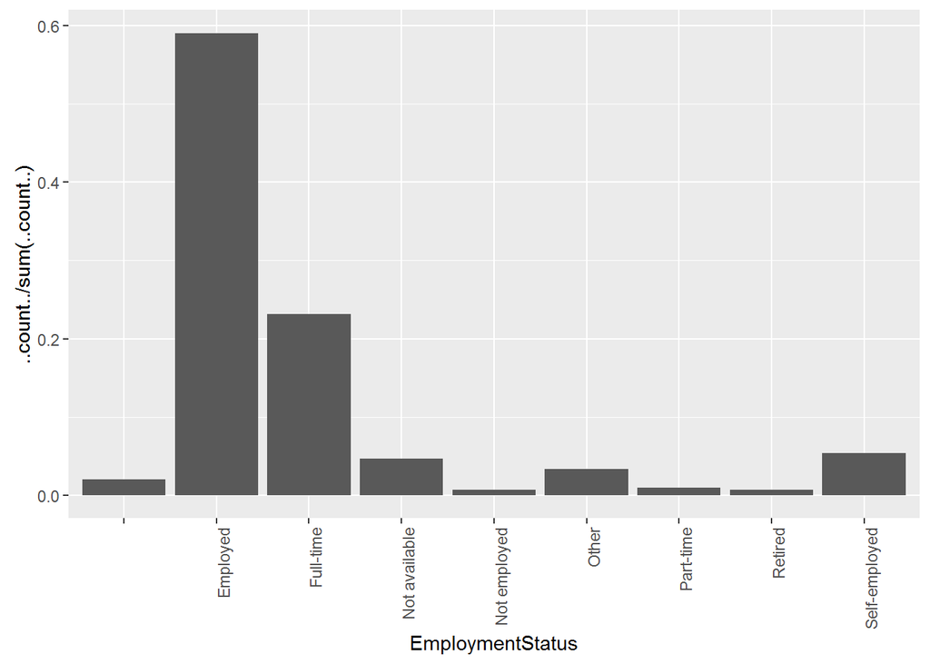

```r
#interested feature: EmploymentStatus
ggplot(subset(df,!is.na(EmploymentStatus)),aes(x=EmploymentStatus)) +
  geom_bar(aes(y=..count../sum(..count..))) +
  theme(axis.text.x = element_text(angle = 90, hjust = 1))
```

```r
summary(df$EmploymentStatus)
```

```
##                    Employed     Full-time Not available  Not employed
##          2255         67322         26355          5347           835
##         Other     Part-time       Retired Self-employed
##          3806          1088           795          6134
```

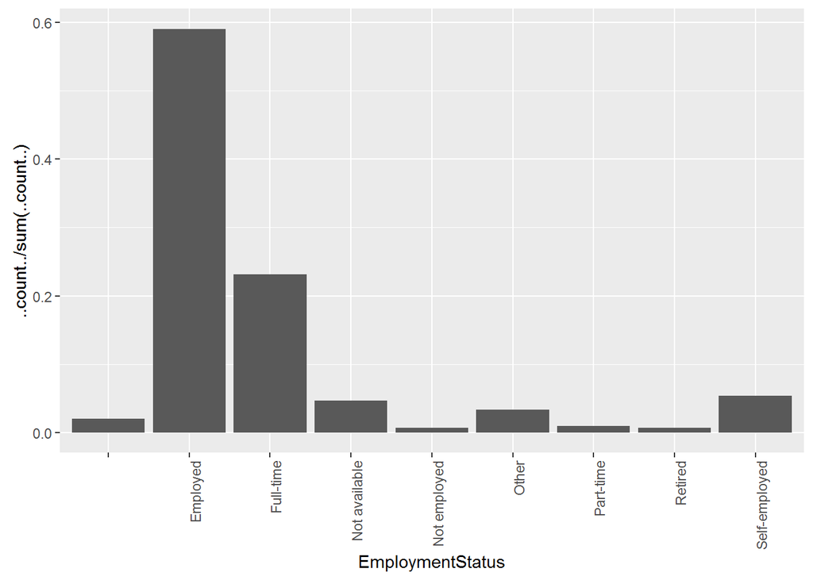

```r
#interested feature: EmploymentStatus
ggplot(df,aes(x=EmploymentStatus)) +
  geom_bar(aes(y=..count../sum(..count..))) +
  theme(axis.text.x = element_text(angle = 90, hjust = 1))
```

```r
summary(df$EmploymentStatus)
```

```
##                    Employed     Full-time Not available  Not employed
##          2255         67322         26355          5347           835
##         Other     Part-time       Retired Self-employed
##          3806          1088           795          6134
```

```r
table(df$Term)
```

```
##
##    12    36    60
##  1614 87778 24545
```

```r
table(df$IncomeRange)
```

```
##
##             $0      $1-24,999      $100,000+ $25,000-49,999 $50,000-74,999
##            621           7274          17337          32192          31050
## $75,000-99,999  Not displayed   Not employed
##          16916           7741            806
```

```r
summary(df$LoanOriginalAmount)
```

```
##    Min. 1st Qu.  Median    Mean 3rd Qu.    Max.
##    1000    4000    6500    8337   12000   35000
```

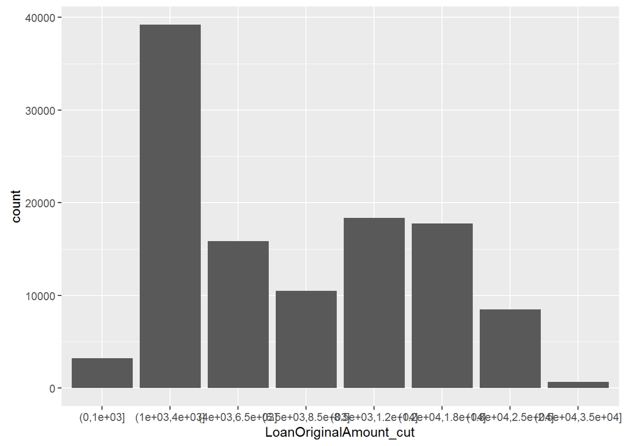

```r
df$LoanOriginalAmount_cut<-cut(df$LoanOriginalAmount,c(0,1000,4000,6500,8500,12000,18000,25000,35000))
ggplot(df,aes(x=LoanOriginalAmount_cut)) +
  geom_bar()
```

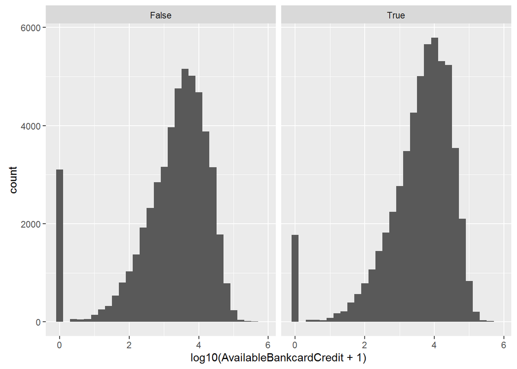

```r
qplot(x=log10(AvailableBankcardCredit+1),data=subset(df,!is.na(AvailableBankcardCredit)))+
  #scale_x_continuous(limits = c(0,200000),breaks=seq(0,200000,100))+
  facet_wrap(~IsBorrowerHomeowner)
```

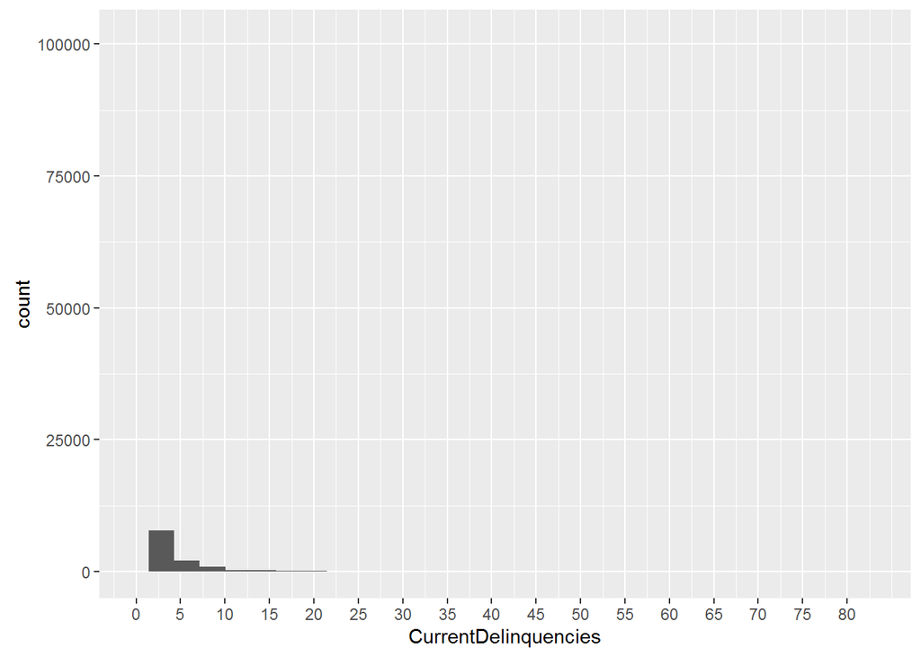

```r
qplot(x=CurrentDelinquencies,data=subset(df,!is.na(CurrentDelinquencies)))+
  scale_x_continuous(limits = c(0,83),breaks=seq(0,83,5))
```

# Univariate Analysis

### What is the structure of your dataset?

LoanOriginalAmount: Min. 1st Qu. Median Mean 3rd Qu. Max. 1000 4000 6500 8337 12000 35000 Term: 12 36 60 1614 87778 24545 AvailableBankcardCredit: Min. 1st Qu. Median Mean 3rd Qu. Max. NA’s 0 880 4100 11210 13180 646300 7544 LoanStatus: Cancelled, Chargedoff,Completed,Current,Defaulted, FinalPaymentInProgress, Past Due EmploymentStatus:Employed, Full-time, Not available, Not employed, Other, Part-time, Retired, Self-employed ProsperRating..Alpha.: AA, A, B, C, D, E, HR

### What is/are the main feature(s) of interest in your dataset?

LoanOriginalAmount,IsBorrowerHomeowner,AvailableBankcardCredit,StatedMonthlyIncome,Occupation,EmploymentStatus

### What other features in the dataset do you think will help support your investigation into your feature(s) of interest?

LoanOriginationDate,Term,MonthlyLoanPayment,BorrowerAPR,LP_ServiceFees,ProsperRating

### Did you create any new variables from existing variables in the dataset?

Yes: df$LoanOriginalAmount_cut<-cut(df$LoanOriginalAmount,c(0,1000,4000,6500,8500,12000,18000,25000,35000))

### Of the features you investigated, were there any unusual distributions? Did you perform any operations on the data to tidy, adjust, or change the form of the data? If so, why did you do this?

I log-transformed the AvailableBankcardCredit.

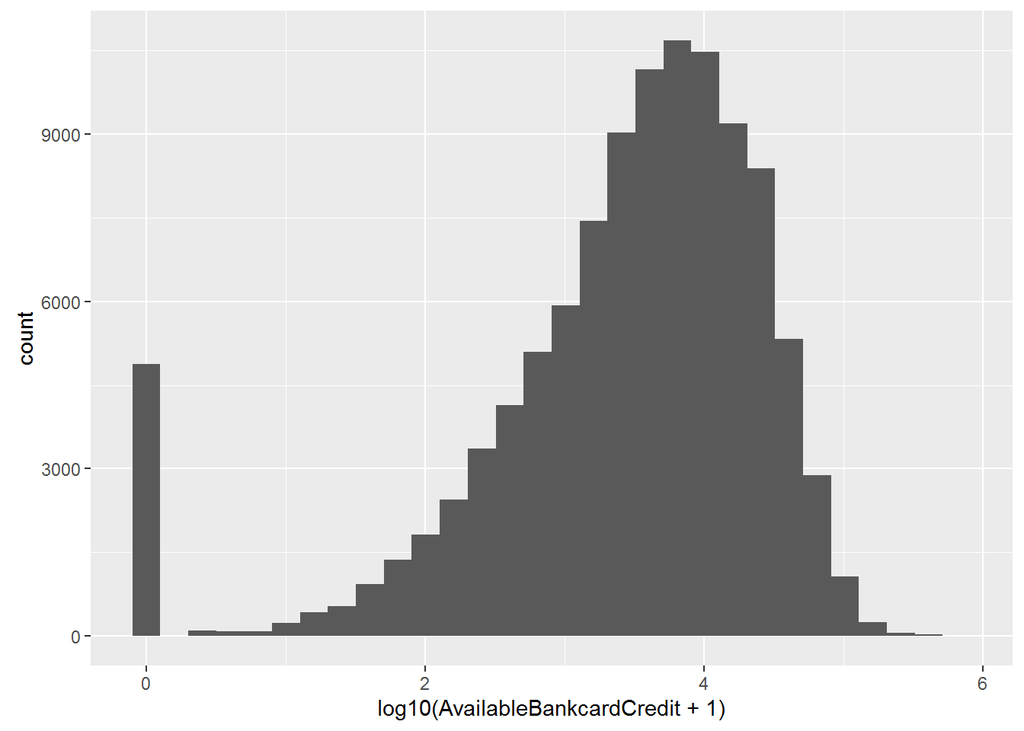

```r
qplot(x=log10(AvailableBankcardCredit+1),data=subset(df,!is.na(AvailableBankcardCredit)))
```

```r
#setwd("E:/learning_R")
df<- read.csv("prosperLoanData.csv")
df.Credit_and_income_by_Occupation_owner.long<-df%>%
  filter(!is.na(IsBorrowerHomeowner))%>%
  filter(!is.na(AvailableBankcardCredit))%>%
  filter(!is.na(Occupation))%>%
  group_by(Occupation,IsBorrowerHomeowner)%>%
  summarise(mean_Credit=mean(AvailableBankcardCredit),
            mean_income=mean(StatedMonthlyIncome),
            median_income=median(StatedMonthlyIncome),
            n=n())%>%
  ungroup()%>%
  arrange(Occupation)
df.meanCredit_by_Occupation_owner.wide<-dcast(
  df.Credit_and_income_by_Occupation_owner.long,
  Occupation~IsBorrowerHomeowner,
  value.var ="mean_Credit" )
df.meanIncome_by_Occupation_owner.wide<-dcast(
  df.Credit_and_income_by_Occupation_owner.long,
  Occupation~IsBorrowerHomeowner,
  value.var ="mean_income" )
df.medianIncome_by_Occupation_owner.wide<-dcast(
  df.Credit_and_income_by_Occupation_owner.long,
  Occupation~IsBorrowerHomeowner,
  value.var ="median_income" )
```

# Bivariate Plots Section

```
## Source: local data frame [10 x 2]
##
##                  Occupation     n
##                      (fctr) (int)
## 1                     Other 28617
## 2              Professional 13628
## 3       Computer Programmer  4478
## 4                 Executive  4311
## 5                   Teacher  3759
## 6  Administrative Assistant  3688
## 7                   Analyst  3602
## 8                            3588
## 9        Sales - Commission  3446
## 10           Accountant/CPA  3233
```

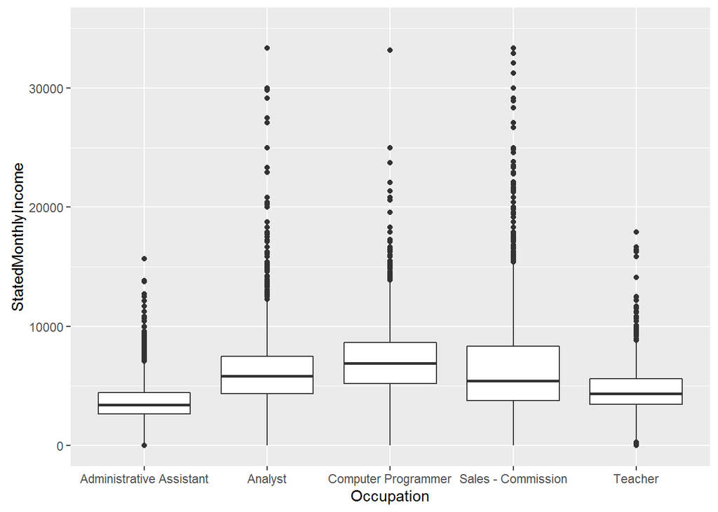

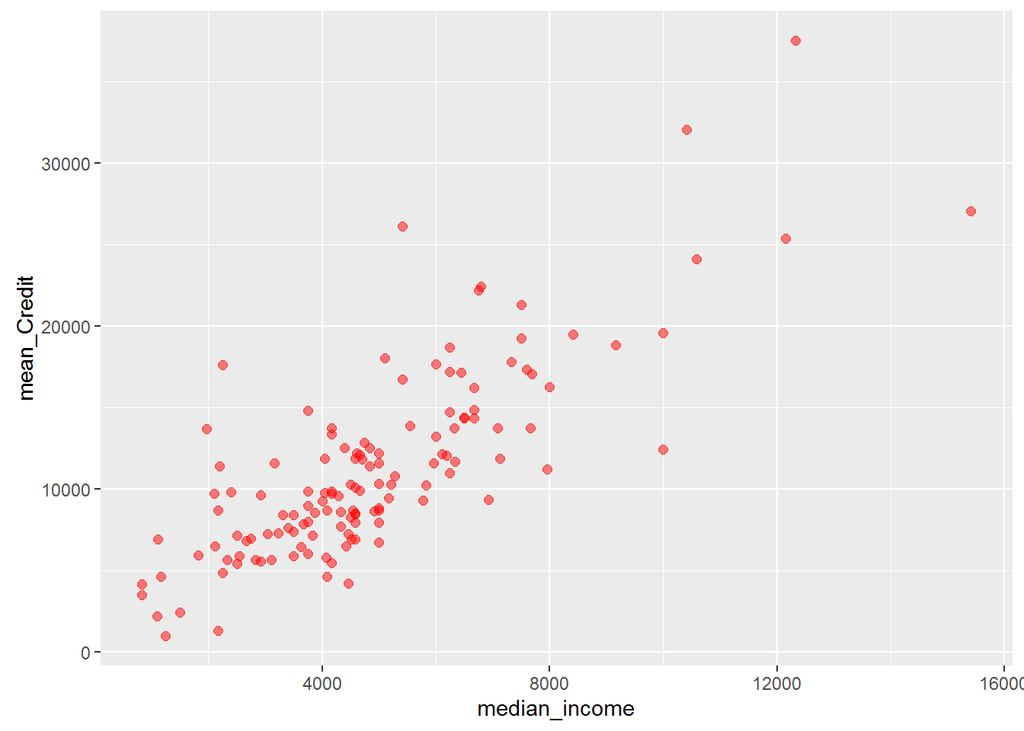

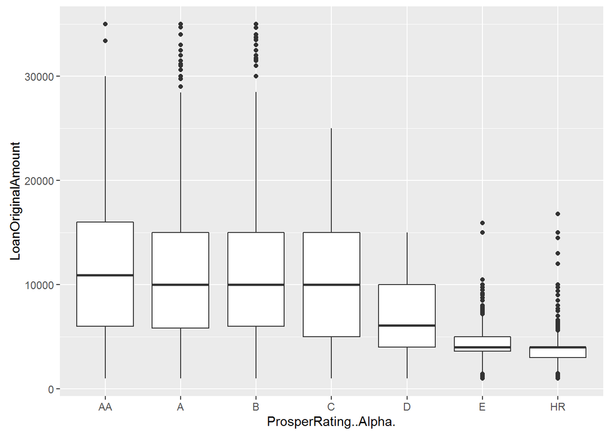

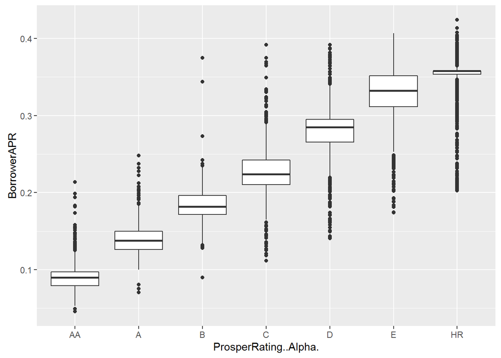

# Bivariate Analysis

### Talk about some of the relationships you observed in this part of the investigation. How did the feature(s) of interest vary with other features in the dataset?

```r
cor.test(df.Credit_and_income_by_Occupation_owner.long$median_income,df.Credit_and_income_by_Occupation_owner.long$mean_Credit)
```

```
##
##  Pearson's product-moment correlation
##
## data:  df.Credit_and_income_by_Occupation_owner.long$median_income and df.Credit_and_income_by_Occupation_owner.long$mean_Credit
## t = 15.342, df = 133, p-value < 2.2e-16
## alternative hypothesis: true correlation is not equal to 0
## 95 percent confidence interval:
##  0.7288239 0.8530914
## sample estimates:
##       cor
## 0.7993492
```

Generally speaking, the loan original Amount tends to be larger as the ProsperRating goes higher. The loan original amount squeezes a lot when the prosper rating drop from C to D. The gap between other ratings are not that huge.

### Did you observe any interesting relationships between the other features (not the main feature(s) of interest)?

The loanee with home ownership generally has a higher credit and state income than the ones without ownership. The state monthly income of loanees vary a lot among different occupations. Even within the same occupation, the there is huge variance for some particular occupation. Some outlier can reach even 3 or 4 times as the mean income. ### What was the strongest relationship you found? For a certain occupation, the mean credit and median come are strongly related. The correlation between them is as high as 0.799. The loanee has to pay more interests if the loan has a lower ProsperRating.

# Multivariate Plots Section

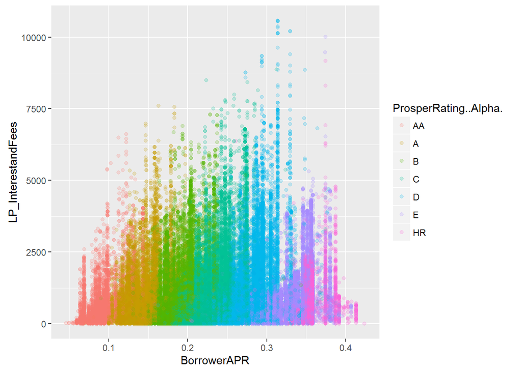

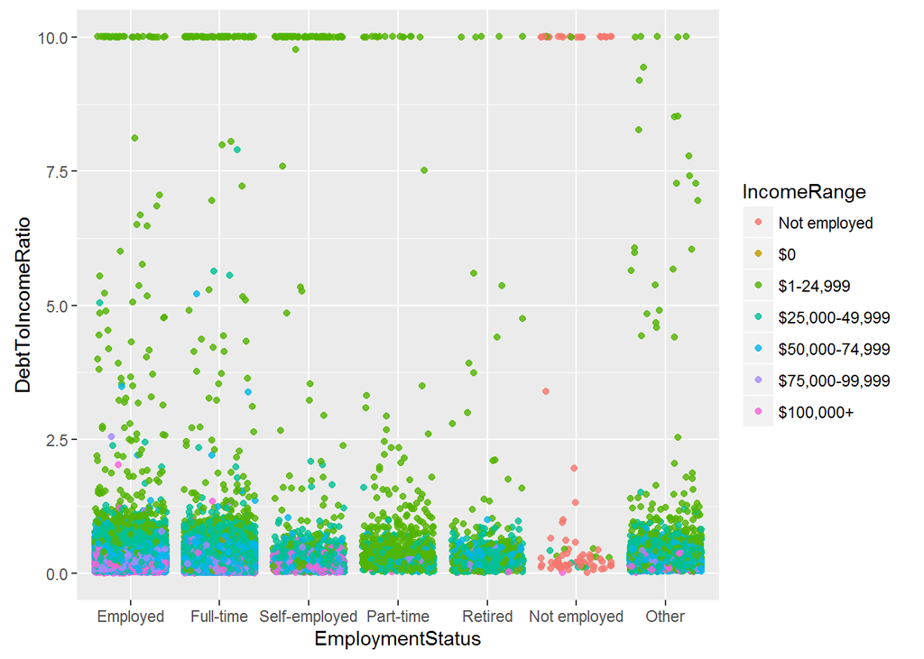

# Multivariate Analysis

### Talk about some of the relationships you observed in this part of the investigation. Were there features that strengthened each other in terms of looking at your feature(s) of interest?

DebtToIncomeRatio is strongly related to IncomeRange. The people who has the DebtToIncomeRatio higher than 1.25,are mostly in the range of $1-24999 for their income or not employed. Most people with part-time job have a low IncomeRange. For people who have a DebtToIncomeRatio higher than 10, they are all in the range of $1-24999 for their income or not employed.

### Were there any interesting or surprising interactions between features?

The Borrower’s Annual Percentage Rate is closely related to the ProsperRating of the Loan. The loan with a higher rating trend to have a lower APR.But the borrower of the low rating loan has to pay more interest for the loan annually. The interest and fee of most loans are less than 5000.

# Final Plots and Summary

### Plot One

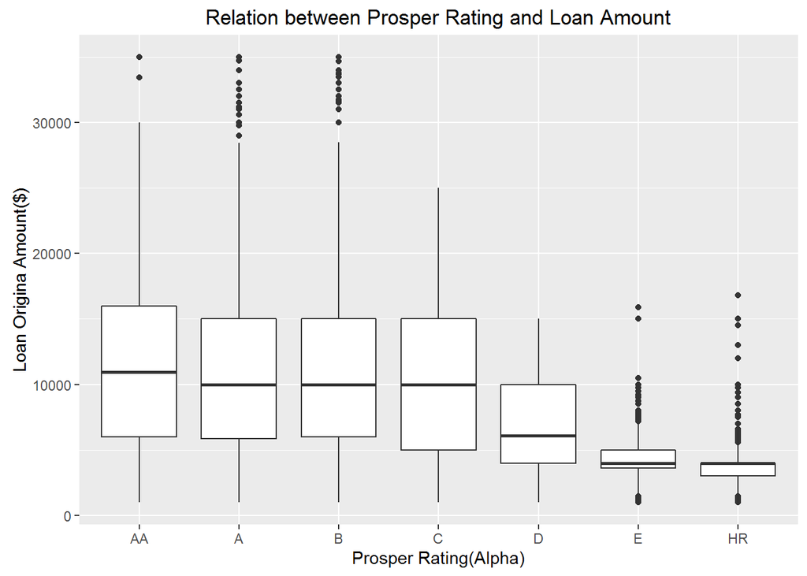

### Description One

There is slightly loan amount difference between the prosper rating “AA”,“A”,“B”,“C”. But when the rating get forward lower, the amount drop steeply. We can also find that, the amount distribution for rating “E” and “HR”, are not very uniformly distributed.

### Plot Two

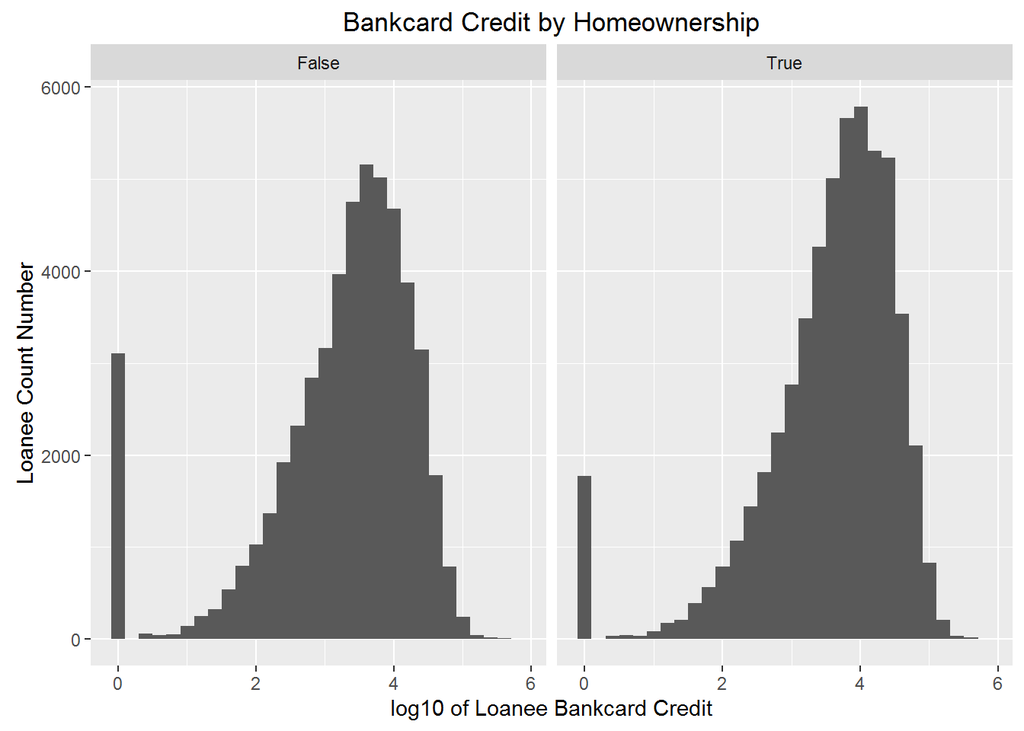

### Description Two

The available credit for most people is between 1000-12000$. From the plot , we can find that , about 5000 loanees do not have available credit. Generally speaking, Loanees who have a homeownership possess a higher available credit.

### Plot Three

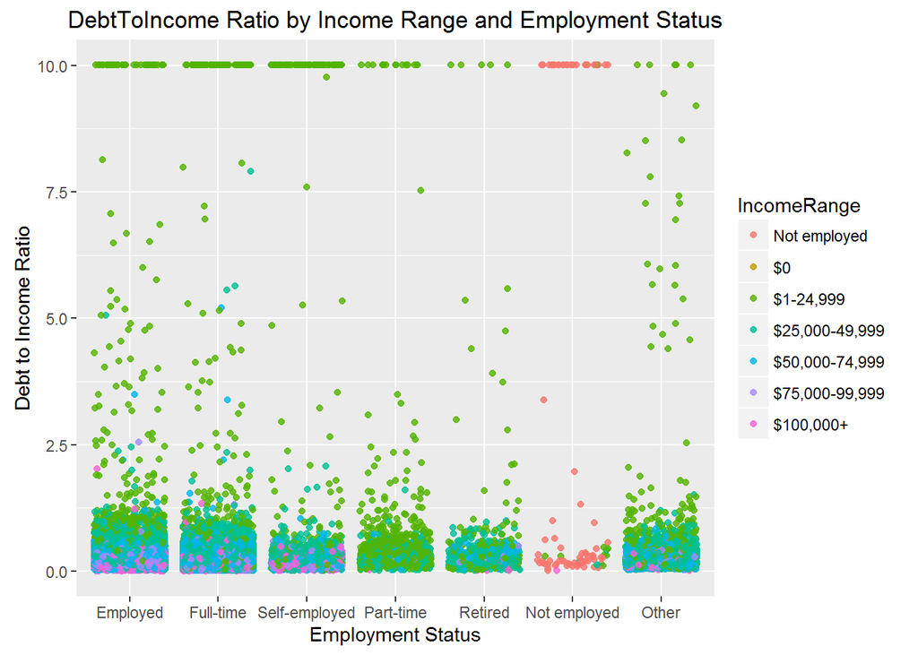

# Reflection

The biggest challenge that i have met in this report is that, i am not familiar with the data variable.I have to firstly figure out the meaning of the variables, and then pick up some interesting ones. For the interested variables, i do not know the relation between them. I have to guess their potential connection, and choose corresponding plot type to examine my hypothesis, over and over again. Finally, i get some meaningful result according to my understanding. Another problem is that, when i tried to use Bankcard Credit as x axis value. The range is so huge. So insteadly, i use log10 value of the credits, the plot make more sense then. The limitation of my exploration is that, 1. the dataset is big enough. So the result must be influenced by fortuity. 2. I didn’t construct the cleaning process to delete the outliers. 3. Some critical information about the loanees are not included in the data set. For example, age, sex, education level, height,weight